# Milk Yield

Evangelina

2023-07-18

```
## [conflicted] Will prefer dplyr::select over any other package.
## [conflicted] Will prefer dplyr::filter over any other package.
```

# Milk yield

Data summary

| Name | Piped data |
| --- | --- |
| Number of rows | 77 |
| Number of columns | 13 |
| _______________________ |  |
| Column type frequency: |  |
| numeric | 13 |
| ________________________ |  |
| Group variables | None |

**Variable type: numeric**

| skim_variable | n_missing | complete_rate | mean | sd | p0 | p25 | p50 | p75 | p100 | hist |
| --- | --- | --- | --- | --- | --- | --- | --- | --- | --- | --- |
| vacination | 0 | 1 | 2.52 | 0.60 | 1 | 2 | 3 | 3 | 3.0 | ▁▁▅▁▇ |
| prepartum | 0 | 1 | 2.36 | 0.63 | 1 | 2 | 2 | 3 | 3.0 | ▁▁▇▁▇ |
| experience | 0 | 1 | 3.10 | 1.06 | 1 | 2 | 4 | 4 | 4.0 | ▁▅▁▂▇ |
| capacitations | 0 | 1 | 1.60 | 0.77 | 1 | 1 | 1 | 2 | 3.0 | ▇▁▃▁▂ |
| rearing_system | 0 | 1 | 1.86 | 0.47 | 1 | 2 | 2 | 2 | 2.5 | ▂▁▁▇▂ |
| realiza_calostrado | 0 | 1 | 1.83 | 0.70 | 1 | 1 | 2 | 2 | 3.0 | ▆▁▇▁▃ |
| calostrum_feeding_num | 0 | 1 | 1.58 | 0.66 | 1 | 1 | 1 | 2 | 3.0 | ▇▁▆▁▂ |
| clostrum_feeding_vol | 0 | 1 | 3.31 | 1.15 | 1 | 2 | 3 | 4 | 5.0 | ▂▅▆▇▃ |
| liquid_feeding_volume | 0 | 1 | 2.39 | 0.52 | 1 | 2 | 2 | 3 | 3.0 | ▁▁▇▁▆ |
| hygiene | 0 | 1 | 2.25 | 0.75 | 1 | 2 | 2 | 3 | 3.0 | ▃▁▇▁▇ |
| disease_ranking | 0 | 1 | 1.86 | 1.35 | 1 | 1 | 1 | 3 | 5.0 | ▇▁▁▁▁ |
| feed_cows | 0 | 1 | 2.29 | 0.45 | 2 | 2 | 2 | 3 | 3.0 | ▇▁▁▁▃ |
| milk_yield | 0 | 1 | 7516.60 | 1400.89 | 4300 | 6800 | 7625 | 8235 | 11590.0 | ▂▅▇▁▁ |

## Reg lineal multiple

```
##
## Call:
## lm(formula = milk_yield ~ ., data = dat_milk)
##
## Residuals:
##     Min      1Q  Median      3Q     Max
## -3386.5  -611.1    23.8   612.3  2884.1
##
## Coefficients:
##                       Estimate Std. Error t value Pr(>|t|)
## (Intercept)            1207.23    1486.32   0.812   0.4197
## vacination              151.19     267.39   0.565   0.5738
## prepartum               285.49     263.24   1.085   0.2822
## experience              174.30     143.44   1.215   0.2288
## capacitations           -88.49     221.71  -0.399   0.6911
## rearing_system          129.54     311.59   0.416   0.6790
## realiza_calostrado      268.73     226.23   1.188   0.2393
## calostrum_feeding_num  -172.97     297.78  -0.581   0.5634
## clostrum_feeding_vol    344.77     175.44   1.965   0.0537 .
## liquid_feeding_volume    57.89     326.27   0.177   0.8597
## hygiene                 250.46     205.51   1.219   0.2274
## disease_ranking         125.64     122.49   1.026   0.3089
## feed_cows              1014.66     382.81   2.651   0.0101 *
## ---
## Signif. codes:  0 '***' 0.001 '**' 0.01 '*' 0.05 '.' 0.1 ' ' 1
##
## Residual standard error: 1208 on 64 degrees of freedom
## Multiple R-squared:  0.3736, Adjusted R-squared:  0.2562
## F-statistic: 3.181 on 12 and 64 DF,  p-value: 0.001313
```

```
## Start:  AIC=1104.68
## milk_yield ~ vacination + prepartum + experience + capacitations +
##     rearing_system + realiza_calostrado + calostrum_feeding_num +
##     clostrum_feeding_vol + liquid_feeding_volume + hygiene +
##     disease_ranking + feed_cows
##
##                         Df Sum of Sq       RSS    AIC
## - liquid_feeding_volume  1     45959  93468251 1102.7
## - capacitations          1    232551  93654843 1102.9
## - rearing_system         1    252298  93674590 1102.9
## - vacination             1    466673  93888965 1103.1
## - calostrum_feeding_num  1    492507  93914799 1103.1
## - disease_ranking        1   1535734  94958026 1103.9
## - prepartum              1   1716900  95139192 1104.1
## - realiza_calostrado     1   2059747  95482039 1104.4
## - experience             1   2155505  95577797 1104.4
## - hygiene                1   2168138  95590430 1104.5
## <none>                                93422292 1104.7
## - clostrum_feeding_vol   1   5637255  99059547 1107.2
## - feed_cows              1  10255104 103677396 1110.7
##
## Step:  AIC=1102.72
## milk_yield ~ vacination + prepartum + experience + capacitations +
##     rearing_system + realiza_calostrado + calostrum_feeding_num +
##     clostrum_feeding_vol + hygiene + disease_ranking + feed_cows
##
##                         Df Sum of Sq       RSS    AIC
## - rearing_system         1    245348  93713599 1100.9
## - capacitations          1    277398  93745648 1101.0
## - vacination             1    511978  93980229 1101.1
## - calostrum_feeding_num  1    629572  94097823 1101.2
## - disease_ranking        1   1612880  95081131 1102.0
## - prepartum              1   1813555  95281806 1102.2
## - realiza_calostrado     1   2084212  95552462 1102.4
## - hygiene                1   2157429  95625680 1102.5
## - experience             1   2331302  95799553 1102.6
## <none>                                93468251 1102.7
## + liquid_feeding_volume  1     45959  93422292 1104.7
## - clostrum_feeding_vol   1   7206618 100674869 1106.4
## - feed_cows              1  10742854 104211105 1109.1
```

[output cut: 101 more lines]

```
##
##                         Df Sum of Sq       RSS    AIC
## <none>                                97286545 1093.8
## - realiza_calostrado     1   2642489  99929035 1093.9
## - experience             1   2807778 100094323 1094.0
## - hygiene                1   3163581 100450126 1094.3
## + prepartum              1   1033053  96253493 1095.0
## + disease_ranking        1    613650  96672895 1095.3
## + rearing_system         1    396812  96889733 1095.5
## + liquid_feeding_volume  1    378924  96907622 1095.5
## + vacination             1    373075  96913471 1095.5
## + capacitations          1    194969  97091577 1095.7
## + calostrum_feeding_num  1     49611  97236934 1095.8
## - clostrum_feeding_vol   1  13444416 110730961 1101.8
## - feed_cows              1  14848973 112135518 1102.7
```

```
##
## Call:
## lm(formula = milk_yield ~ experience + realiza_calostrado + clostrum_feeding_vol +
##     hygiene + feed_cows, data = dat_milk)
##
## Residuals:
##     Min      1Q  Median      3Q     Max
## -3198.7  -539.3   -64.7   644.8  2818.7
##
## Coefficients:
##                      Estimate Std. Error t value Pr(>|t|)
## (Intercept)            2093.1      944.8   2.215  0.02994 *
## experience              190.4      133.0   1.431  0.15668
## realiza_calostrado      291.6      210.0   1.389  0.16926
## clostrum_feeding_vol    382.2      122.0   3.132  0.00252 **
## hygiene                 280.7      184.8   1.519  0.13308
## feed_cows              1051.0      319.3   3.292  0.00155 **
## ---
## Signif. codes:  0 '***' 0.001 '**' 0.01 '*' 0.05 '.' 0.1 ' ' 1
##
## Residual standard error: 1171 on 71 degrees of freedom
## Multiple R-squared:  0.3477, Adjusted R-squared:  0.3018
## F-statistic:  7.57 on 5 and 71 DF,  p-value: 9.582e-06
```

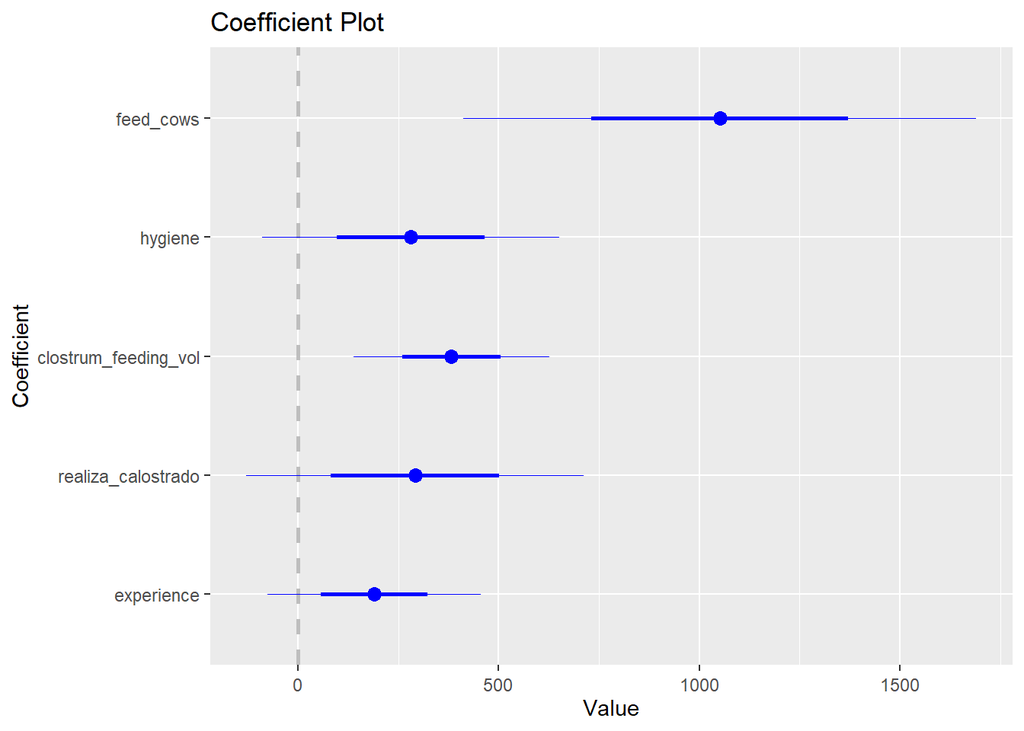

En este grafico podemos ver todas las variables que tienen efecto sobre milk_yield aumentan (segun el modelo solo la alimentacion de las vacas y el volumen de calostro tienen efecto).

- Importancia relativa

Analizo la importancia relativa de las variables presentes en el modelo

```
## Response variable: milk_yield
## Total response variance: 1962481
## Analysis based on 77 observations
##
## 5 Regressors:
## experience realiza_calostrado clostrum_feeding_vol hygiene feed_cows
## Proportion of variance explained by model: 34.77%
## Metrics are normalized to sum to 100% (rela=TRUE).
##
## Relative importance metrics:
##
##                             car
## experience           0.06167898
## realiza_calostrado   0.12773496
## clostrum_feeding_vol 0.32909422
## hygiene              0.11116978
## feed_cows            0.37032205
```

Se puede ver que el tipo de alimentacion de las vacas tiene una importacia del 37% sobre produccion de leche, y el volumen de calostro del 33%.

```
##
##         low mid high
##   4300    1   0    0
##   5000    3   0    0
##   5490    2   0    0
##   5500    4   0    0
##   5600    2   0    0
##   6100    2   0    0
##   6500    4   0    0
##   6710    1   0    0
##   6800    1   0    0
##   7000    8   0    0
##   7015    0   3    0
##   7320    0   1    0
##   7500    0   3    0
```

[output cut: 22 more lines]

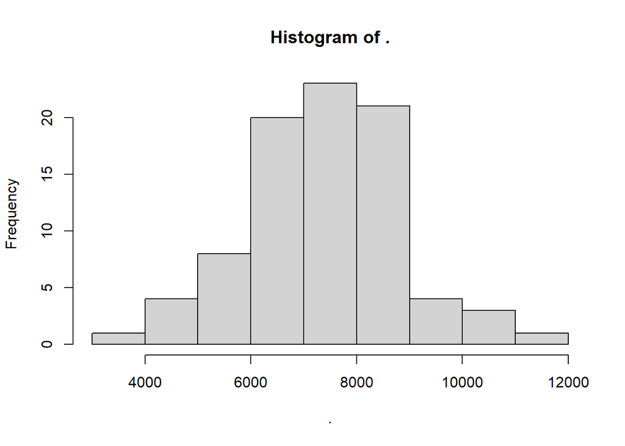

```
##     vacination prepartum experience capacitations rearing_system
## 1            1         3          4             1            2.0
## 2            2         3          3             1            2.0
## 3            3         3          4             2            2.0
## 4            3         2          4             2            2.5
## 5            3         2          2             1            1.0
## 6            2         1          2             2            2.0
## 7            2         1          2             2            2.0
## 8            2         1          4             1            1.0
## 9            2         2          3             1            2.0
## 10           3         2          1             1            2.5
## 11           3         2          4             1            2.0
## 12           1         3          4             1            2.0
## 13           2         2          2             1            2.0
## 14           2         3          4             1            2.5
```

[output cut: 393 more lines]

```
## Start:  AIC=270.28
## milk_yield_band ~ liquid_feeding_volume + experience + hygiene +
##     capacitations + realiza_calostrado + feed_cows
##
##                         Df Deviance    AIC
## - liquid_feeding_volume  1   256.46 268.46
## - capacitations          1   256.69 268.69
## <none>                       256.28 270.28
## - hygiene                1   262.99 274.99
## - realiza_calostrado     1   266.45 278.45
## - experience             1   271.50 283.50
## - feed_cows              1   272.80 284.80
##
## Step:  AIC=268.46
## milk_yield_band ~ experience + hygiene + capacitations + realiza_calostrado +
##     feed_cows
##
##                         Df Deviance    AIC
## - capacitations          1   256.97 266.97
## <none>                       256.46 268.46
## + liquid_feeding_volume  1   256.28 270.28
## - hygiene                1   263.56 273.56
## - realiza_calostrado     1   267.13 277.13
## - feed_cows              1   272.95 282.95
## - experience             1   273.37 283.37
##
## Step:  AIC=266.97
## milk_yield_band ~ experience + hygiene + realiza_calostrado +
##     feed_cows
##
##                         Df Deviance    AIC
## <none>                       256.97 266.97
## + capacitations          1   256.46 268.46
## + liquid_feeding_volume  1   256.69 268.69
## - hygiene                1   263.59 271.59
## - realiza_calostrado     1   267.18 275.18
## - feed_cows              1   273.16 281.16
## - experience             1   275.03 283.03
```

```
##
## Call:
## glm(formula = milk_yield_band ~ experience + hygiene + realiza_calostrado +
##     feed_cows, family = binomial, data = dat2, weights = clostrum_feeding_vol)
##
## Coefficients:
##                    Estimate Std. Error z value Pr(>|z|)
## (Intercept)         -7.5545     1.3834  -5.461 4.74e-08 ***
## experience           0.6260     0.1547   4.048 5.17e-05 ***
## hygiene              0.5327     0.2096   2.541 0.011038 *
## realiza_calostrado   0.7689     0.2512   3.061 0.002206 **
## feed_cows            1.7546     0.4933   3.557 0.000375 ***
## ---
## Signif. codes:  0 '***' 0.001 '**' 0.01 '*' 0.05 '.' 0.1 ' ' 1
##
## (Dispersion parameter for binomial family taken to be 1)
##
##     Null deviance: 315.66  on 76  degrees of freedom
## Residual deviance: 256.97  on 72  degrees of freedom
## AIC: 266.97
##
## Number of Fisher Scoring iterations: 4
```

|  | milk yield band |  |  |
| --- | --- | --- | --- |
| Predictors | Odds Ratios | CI | p |
| (Intercept) | 0.00 | 0.00 – 0.01 | **<0.001** |
| experience | 1.87 | 1.39 – 2.56 | **<0.001** |
| hygiene | 1.70 | 1.13 – 2.59 | **0.011** |
| realiza calostrado | 2.16 | 1.34 – 3.59 | **0.002** |
| feed cows | 5.78 | 2.35 – 16.68 | **<0.001** |
| Observations | 77 |  |  |
| R<sup>2</sup> Tjur | 0.096 |  |  |

```
## $odds_data
## # A tibble: 4 × 4
##      OR lower upper vars
##   <dbl> <dbl> <dbl> <chr>
## 1  1.87  1.39  2.56 experience
## 2  1.70  1.13  2.59 hygiene
## 3  2.16  1.34  3.59 realiza_calostrado
## 4  5.78  2.35 16.7  feed_cows
##
## $odds_plot
```

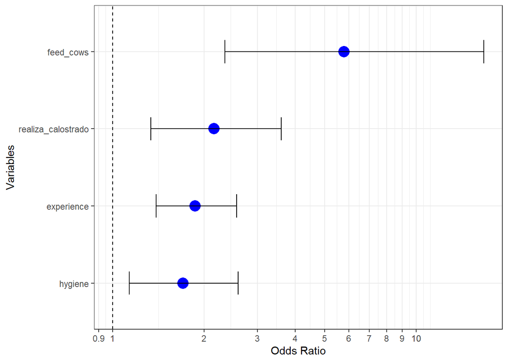

## Random forest

```
##  [1] "vacination"            "prepartum"             "experience"
##  [4] "capacitations"         "rearing_system"        "realiza_calostrado"
##  [7] "calostrum_feeding_num" "clostrum_feeding_vol"  "liquid_feeding_volume"
## [10] "hygiene"               "disease_ranking"       "feed_cows"
## [13] "milk_yield"            "milk_yield_band"
```

## Arbol de clasificacion

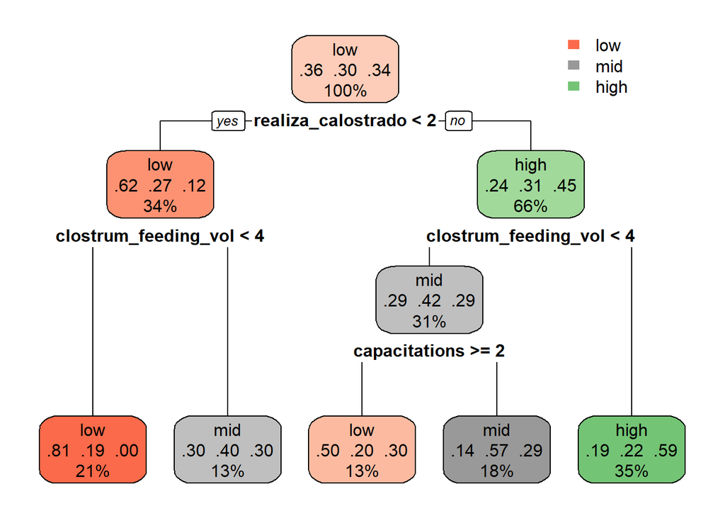

En este arbol de prediccion se ve que si e metodo de calostrado era al pie de la madre, la produccion de leche era baja en un 34% de los casos y si a su vez se suministraba un volumen de calostro menor a 4 litros antes de las 24 horas de nacido la prod. era baja en 21 % de los establecimientos encuestads. Por otro lado si el calostro era dado de forma arificial, y se suministraba un volumen antes de las 24 hs superior a 4, la produccion de leche era alta

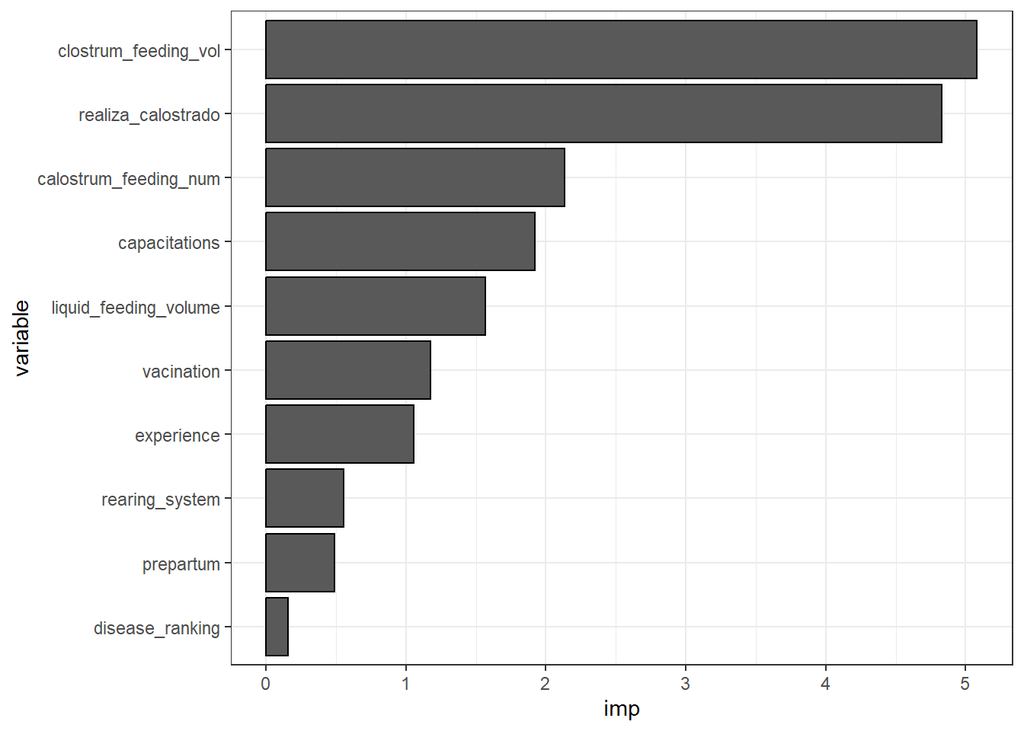

## Factorizo variables predictoras

Si factorizo las variables predictoras, el modelo queda de la siguiente forma:

```
##    prepartum experience capacitations rearing_system realiza_calostrado
## 1          3          4             1              2                  1
## 2          3          3             1              2                  2
## 3          3          4             2              2                  3
## 4          2          2             1              1                  1
## 5          1          2             2              2                  1
## 6          1          4             1              1                  2
## 7          2          1             1            2.5                  1
## 8          3          4             1            2.5                  1
## 9          3          4             1              2                  2
## 10         1          3             1              1                  2
## 11         2          4             1              2                  2
## 12         2          4             1              2                  2
## 13         2          4             1              2                  2
## 14         2          3             1              2                  1
```

[output cut: 219 more lines]

## Reg. lineal múltiple

```
## Analysis of Variance Table
##
## Response: milk_yield
##                       Df   Sum Sq Mean Sq F value  Pr(>F)
## prepartum              2 13553566 6776783  4.7460 0.01297 *
## experience             3  2208962  736321  0.5157 0.67339
## capacitations          2  7868271 3934136  2.7552 0.07326 .
## rearing_system         2  2944508 1472254  1.0311 0.36408
## realiza_calostrado     2 13803335 6901668  4.8334 0.01205 *
## calostrum_feeding_num  2    76812   38406  0.0269 0.97348
## clostrum_feeding_vol   4 17452775 4363194  3.0557 0.02496 *
## liquid_feeding_volume  2  2123216 1061608  0.7435 0.48064
## hygiene                2  1055310  527655  0.3695 0.69293
## disease_ranking        4  7308639 1827160  1.2796 0.29051
## feed_cows              1  9358264 9358264  6.5539 0.01353 *
## Residuals             50 71394920 1427898
## ---
## Signif. codes:  0 '***' 0.001 '**' 0.01 '*' 0.05 '.' 0.1 ' ' 1
```

```
## Start:  AIC=1111.97
## milk_yield ~ prepartum + experience + capacitations + rearing_system +
##     realiza_calostrado + calostrum_feeding_num + clostrum_feeding_vol +
##     liquid_feeding_volume + hygiene + disease_ranking + feed_cows
##
##                         Df Sum of Sq      RSS    AIC
## - capacitations          2      7057 71401977 1108.0
## - experience             3   2007978 73402898 1108.1
## - rearing_system         2    664017 72058937 1108.7
## - liquid_feeding_volume  2   1046525 72441446 1109.1
## - calostrum_feeding_num  2   1777235 73172155 1109.9
## - hygiene                2   1945585 73340505 1110.0
## - prepartum              2   2273110 73668031 1110.4
## - realiza_calostrado     2   2850905 74245825 1111.0
## <none>                               71394920 1112.0
## - disease_ranking        4   8833922 80228843 1113.0
## - clostrum_feeding_vol   4  14746529 86141450 1118.4
## - feed_cows              1   9358264 80753185 1119.5
##
## Step:  AIC=1107.98
## milk_yield ~ prepartum + experience + rearing_system + realiza_calostrado +
##     calostrum_feeding_num + clostrum_feeding_vol + liquid_feeding_volume +
##     hygiene + disease_ranking + feed_cows
##
##                         Df Sum of Sq      RSS    AIC
## - experience             3   2029173 73431150 1104.1
## - rearing_system         2    687173 72089150 1104.7
## - liquid_feeding_volume  2   1052143 72454120 1105.1
## - calostrum_feeding_num  2   1821761 73223738 1105.9
## - hygiene                2   2007914 73409891 1106.1
## - prepartum              2   2409983 73811960 1106.5
## - realiza_calostrado     2   2923480 74325458 1107.1
## <none>                               71401977 1108.0
## - disease_ranking        4   9845196 81247174 1109.9
## + capacitations          2      7057 71394920 1112.0
## - clostrum_feeding_vol   4  15030495 86432473 1114.7
## - feed_cows              1  10062361 81464338 1116.1
##
## Step:  AIC=1104.14
## milk_yield ~ prepartum + rearing_system + realiza_calostrado +
```

[output cut: 74 more lines]

```
##     disease_ranking + feed_cows
##
##                         Df Sum of Sq      RSS    AIC
## <none>                               79536744 1094.3
## - prepartum              2   5338646 84875390 1095.3
## - disease_ranking        4  10404726 89941470 1095.8
## + hygiene                2   2443230 77093514 1095.9
## + calostrum_feeding_num  2   2104327 77432417 1096.2
## - realiza_calostrado     2   6479027 86015771 1096.3
## + rearing_system         2    872798 78663946 1097.4
## + liquid_feeding_volume  2    738706 78798038 1097.6
## + experience             3   2493964 77042780 1097.8
## + capacitations          2     59433 79477311 1098.2
## - clostrum_feeding_vol   4  16636517 96173261 1100.9
## - feed_cows              1  11401011 90937755 1102.6
```

```
## Analysis of Variance Table
##
## Response: milk_yield
##                      Df   Sum Sq  Mean Sq F value   Pr(>F)
## prepartum             2 13553566  6776783  5.3678 0.007037 **
## realiza_calostrado    2 17423091  8711545  6.9003 0.001951 **
## clostrum_feeding_vol  4 18532420  4633105  3.6698 0.009479 **
## disease_ranking       4  8701746  2175437  1.7231 0.155998
## feed_cows             1 11401011 11401011  9.0306 0.003808 **
## Residuals            63 79536744  1262488
## ---
## Signif. codes:  0 '***' 0.001 '**' 0.01 '*' 0.05 '.' 0.1 ' ' 1
```

Se puede ver que en el modelo las variables preparto, metodo de calostrado, volumen de calostro y alimentacion de las vacas impactan en la produccion de leche, mientras que disease ranking si bien no afecta la produccion de leche igual es incluida en el modelo.

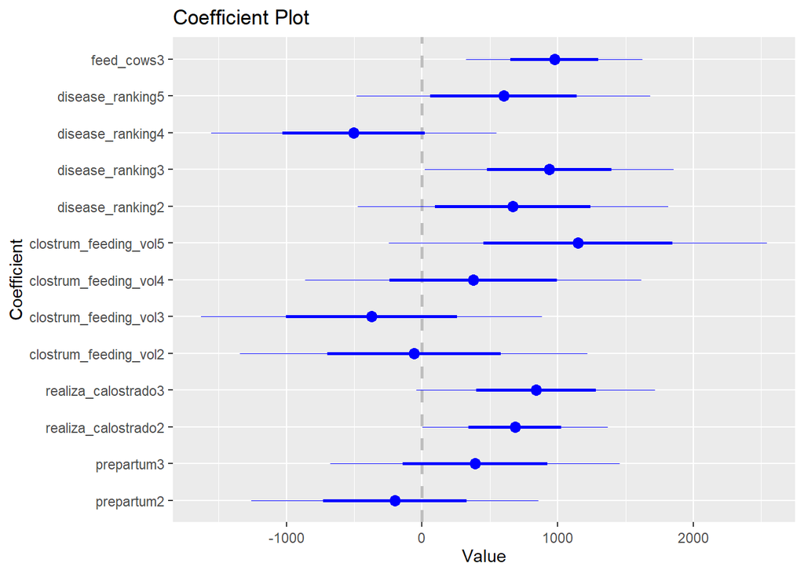

Este grafico muestra que el tipo de alimentacion TMR es el que impacta en la produccion de leche

## Reg log - milk_yield_band.

```
## Start:  AIC=271.69
## milk_yield_band ~ prepartum + liquid_feeding_volume + experience +
##     hygiene + capacitations + realiza_calostrado + feed_cows
##
##                         Df Deviance    AIC
## - liquid_feeding_volume  1   255.87 269.87
## - capacitations          1   256.20 270.20
## - prepartum              1   256.28 270.28
## <none>                       255.69 271.69
## - hygiene                1   261.00 275.00
## - realiza_calostrado     1   266.15 280.15
## - experience             1   270.30 284.30
## - feed_cows              1   272.47 286.47
##
## Step:  AIC=269.87
## milk_yield_band ~ prepartum + experience + hygiene + capacitations +
##     realiza_calostrado + feed_cows
##
##                         Df Deviance    AIC
## - prepartum              1   256.46 268.46
## - capacitations          1   256.49 268.49
## <none>                       255.87 269.87
## + liquid_feeding_volume  1   255.69 271.69
## - hygiene                1   261.45 273.45
## - realiza_calostrado     1   266.81 278.81
## - experience             1   272.05 284.05
## - feed_cows              1   272.61 284.61
##
## Step:  AIC=268.46
## milk_yield_band ~ experience + hygiene + capacitations + realiza_calostrado +
##     feed_cows
##
##                         Df Deviance    AIC
## - capacitations          1   256.97 266.97
## <none>                       256.46 268.46
## + prepartum              1   255.87 269.87
## + liquid_feeding_volume  1   256.28 270.28
## - hygiene                1   263.56 273.56
## - realiza_calostrado     1   267.13 277.13
## - feed_cows              1   272.95 282.95
## - experience             1   273.37 283.37
##
## Step:  AIC=266.97
## milk_yield_band ~ experience + hygiene + realiza_calostrado +
##     feed_cows
##
##                         Df Deviance    AIC
## <none>                       256.97 266.97
## + capacitations          1   256.46 268.46
## + prepartum              1   256.49 268.49
## + liquid_feeding_volume  1   256.69 268.69
## - hygiene                1   263.59 271.59
## - realiza_calostrado     1   267.18 275.18
## - feed_cows              1   273.16 281.16
## - experience             1   275.03 283.03
```

```
## Analysis of Deviance Table (Type II tests)
##
## Response: milk_yield_band
##                    LR Chisq Df Pr(>Chisq)
## experience          18.0580  1  2.143e-05 ***
## hygiene              6.6241  1   0.010061 *
## realiza_calostrado  10.2150  1   0.001393 **
## feed_cows           16.1936  1  5.719e-05 ***
## ---
## Signif. codes:  0 '***' 0.001 '**' 0.01 '*' 0.05 '.' 0.1 ' ' 1
```

```
##
## Call:
## glm(formula = milk_yield_band ~ experience + hygiene + realiza_calostrado +
##     feed_cows, family = binomial, data = dat2, weights = clostrum_feeding_vol)
##
## Coefficients:
##                    Estimate Std. Error z value Pr(>|z|)
## (Intercept)         -7.5545     1.3834  -5.461 4.74e-08 ***
## experience           0.6260     0.1547   4.048 5.17e-05 ***
## hygiene              0.5327     0.2096   2.541 0.011038 *
## realiza_calostrado   0.7689     0.2512   3.061 0.002206 **
## feed_cows            1.7546     0.4933   3.557 0.000375 ***
## ---
## Signif. codes:  0 '***' 0.001 '**' 0.01 '*' 0.05 '.' 0.1 ' ' 1
##
## (Dispersion parameter for binomial family taken to be 1)
##
##     Null deviance: 315.66  on 76  degrees of freedom
## Residual deviance: 256.97  on 72  degrees of freedom
## AIC: 266.97
##
## Number of Fisher Scoring iterations: 4
```

|  | milk yield band |  |  |
| --- | --- | --- | --- |
| Predictors | Odds Ratios | CI | p |
| (Intercept) | 0.00 | 0.00 – 0.01 | **<0.001** |
| experience | 1.87 | 1.39 – 2.56 | **<0.001** |
| hygiene | 1.70 | 1.13 – 2.59 | **0.011** |
| realiza calostrado | 2.16 | 1.34 – 3.59 | **0.002** |
| feed cows | 5.78 | 2.35 – 16.68 | **<0.001** |
| Observations | 77 |  |  |
| R<sup>2</sup> Tjur | 0.096 |  |  |

```
## $odds_data
## # A tibble: 4 × 4
##      OR lower upper vars
##   <dbl> <dbl> <dbl> <chr>
## 1  1.87  1.39  2.56 experience
## 2  1.70  1.13  2.59 hygiene
## 3  2.16  1.34  3.59 realiza_calostrado
## 4  5.78  2.35 16.7  feed_cows
##
## $odds_plot
```

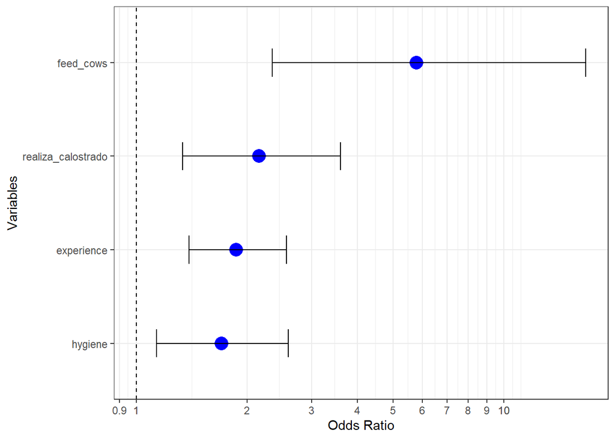

## Árbol de clasificación

```
## n= 77
##
## node), split, n, deviance, yval
##       * denotes terminal node
##
## 1) root 77 149148600 7516.597
##   2) feed_cows< 2.5 55  84741910 7172.673
##     4) realiza_calostrado< 1.5 25  44129740 6806.800
##       8) hygiene< 1.5 7   4658393 5957.857 *
##       9) hygiene>=1.5 18  32464510 7136.944 *
##     5) realiza_calostrado>=1.5 30  34476780 7477.567 *
##   3) feed_cows>=2.5 22  41636970 8376.409
##     6) experience< 2.5 10  19498220 7880.500 *
##     7) experience>=2.5 12  17630100 8789.667 *
```

```
## Call:
## rpart(formula = milk_yield ~ experience + hygiene + realiza_calostrado +
##     feed_cows, data = dat2)
##   n= 77
##
##           CP nsplit rel error   xerror      xstd
## 1 0.15266458      0 1.0000000 1.026765 0.1819810
## 2 0.04405749      1 0.8473354 1.000728 0.1764033
## 3 0.03022919      3 0.7592204 1.093186 0.1865795
## 4 0.01000000      4 0.7289912 1.052834 0.1826885
##
## Variable importance
##          feed_cows            hygiene realiza_calostrado         experience
##                 53                 19                 16                 11
##
## Node number 1: 77 observations,    complexity param=0.1526646
##   mean=7516.597, MSE=1936995
##   left son=2 (55 obs) right son=3 (22 obs)
##   Primary splits:
##       feed_cows          < 2.5 to the left,  improve=0.15266460, (0 missing)
##       realiza_calostrado < 1.5 to the left,  improve=0.13269780, (0 missing)
##       hygiene            < 2.5 to the left,  improve=0.04745872, (0 missing)
##       experience         < 2.5 to the left,  improve=0.02735814, (0 missing)
##
## Node number 2: 55 observations,    complexity param=0.04405749
##   mean=7172.673, MSE=1540762
##   left son=4 (25 obs) right son=5 (30 obs)
##   Primary splits:
##       realiza_calostrado < 1.5 to the left,  improve=0.07240079, (0 missing)
##       experience         < 2.5 to the left,  improve=0.03925117, (0 missing)
##       hygiene            < 1.5 to the left,  improve=0.03734729, (0 missing)
##   Surrogate splits:
##       hygiene    < 1.5 to the left,  agree=0.600, adj=0.12, (0 split)
##       experience < 3.5 to the right, agree=0.564, adj=0.04, (0 split)
##
## Node number 3: 22 observations,    complexity param=0.03022919
##   mean=8376.409, MSE=1892589
##   left son=6 (10 obs) right son=7 (12 obs)
##   Primary splits:
##       experience < 2.5 to the left,  improve=0.1082845, (0 missing)
```

[output cut: 11 more lines]

```
##
## Node number 5: 30 observations
##   mean=7477.567, MSE=1149226
##
## Node number 6: 10 observations
##   mean=7880.5, MSE=1949822
##
## Node number 7: 12 observations
##   mean=8789.667, MSE=1469175
##
## Node number 8: 7 observations
##   mean=5957.857, MSE=665484.7
##
## Node number 9: 18 observations
##   mean=7136.944, MSE=1803584
```

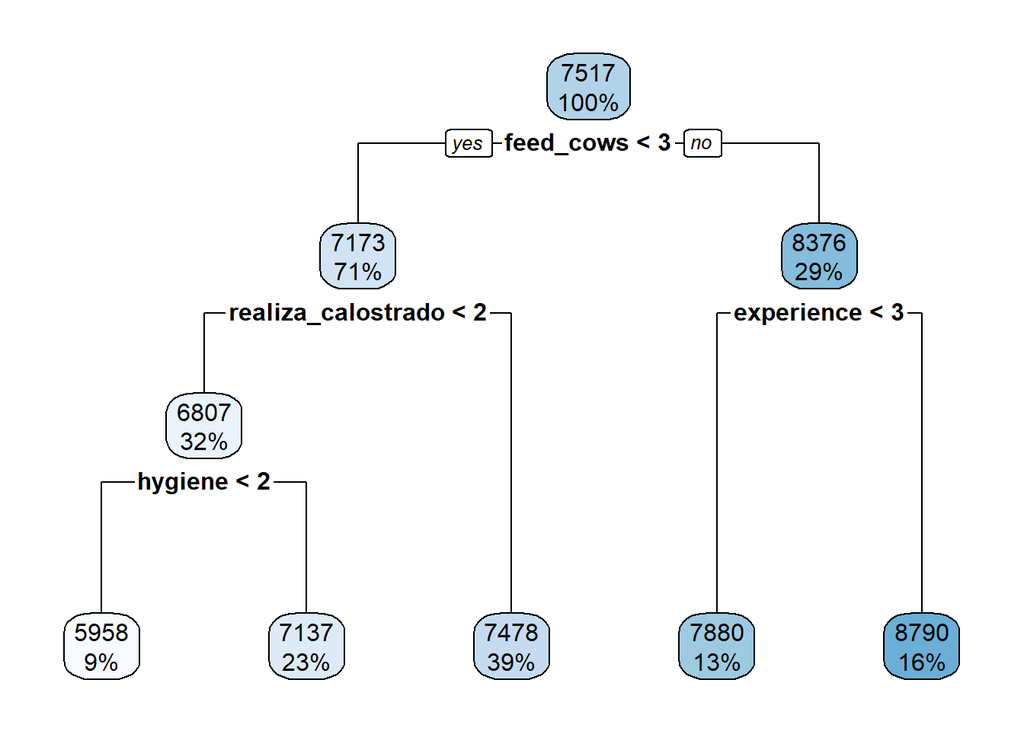

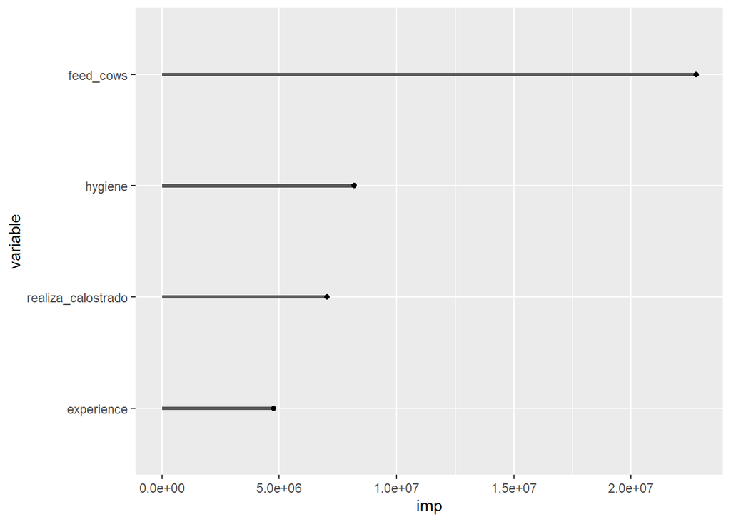

## Random forest

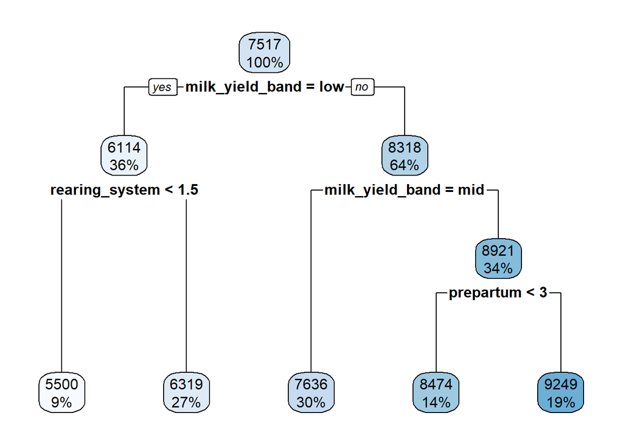

```
## milk_yield is 5500 when
##     milk_yield_band is low
##     rearing_system < 1.5
##
## milk_yield is 6319 when
##     milk_yield_band is low
##     rearing_system >= 1.5
##
## milk_yield is 7636 when
##     milk_yield_band is mid
##
## milk_yield is 8474 when
##     milk_yield_band is high
##     prepartum < 3
##
## milk_yield is 9249 when
##     milk_yield_band is high
##     prepartum >= 3
```

```
##       milk_yield_band    realiza_calostrado  clostrum_feeding_vol
##                  62.3                  12.9                   8.5
##            vacination               hygiene         capacitations
##                   3.9                   3.4                   2.5
##             prepartum        rearing_system calostrum_feeding_num
##                   2.2                   2.1                   2.0
##       disease_ranking
##                   0.2
```

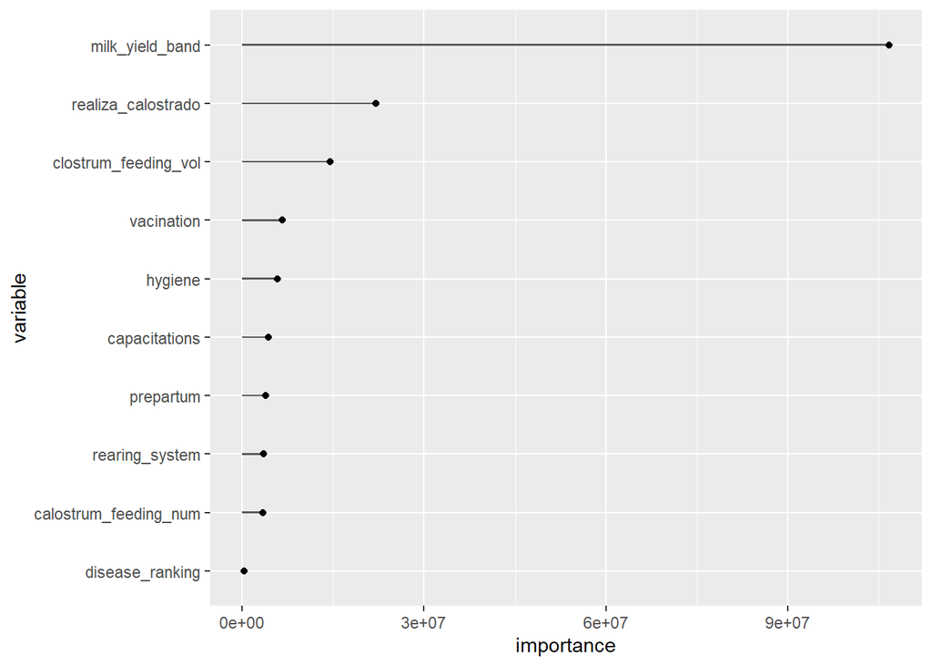